# RAG_WEBSITE_CONTENT

CLASS EXERCISE : BUILDING A RAG PIPLINE BASIS TREDENCE DATA

```python
import requests
from bs4 import BeautifulSoup

# Send a request to the Tredence website
response = requests.get(
    url="https://www.tredence.com/",
)
# Parse the HTML content
soup = BeautifulSoup(response.content, 'html.parser')

# Attempt to find the main content
# Option 1: Try to find the HTML5 <main> tag
main_content_element = soup.find('main')

# Option 2: If <main> is not found, try to find all paragraph tags (<p>)
if not main_content_element:
    paragraphs = soup.find_all('p')
    if paragraphs:
        # Join text from all paragraphs, adding a new line between them
        extracted_text = "\n\n".join([p.get_text(separator=' ', strip=True) for p in paragraphs])
        print(extracted_text)
    else:
        print("No main content found within a <main> tag or any paragraph text.")
        print("You may need to inspect the page manually to find the specific ID or class for the content you want.")
else:
    # If <main> content is found, extract its text
    print(main_content_element.get_text(separator=' ', strip=True))
```

```
Move ideas from
                                                        experimentation to
                                                        reality with
                                                        our accelerators.

Move ideas from experimentation
                                                        to reality with
                                                        our accelerators.

Move ideas from
                                                        experimentation to
                                                        reality with
                                                        our accelerators.

Move ideas from
                                                        experimentation to
                                                        reality with
                                                        our accelerators.

Move ideas from
                                                        experimentation to
                                                        reality with
                                                        our accelerators.

Move ideas from experimentation
                                                        to reality with
                                                        our accelerators.

Move ideas from
                                                        experimentation to
                                                        reality with
                                                        our accelerators.

Move ideas from
                                                        experimentation to
                                                        reality with
                                                        our accelerators.

Move ideas from
                                                        experimentation to
```

[output cut: 321 more lines]

```
Test and Learn Platform (TALP)

On-shelf Availability (OSA)

Customer Cosmos

Sancus – AI-led Data Quality Management

Revenue Growth Management (RGM)

MLWorks

UnityGO

© Copyright . Tredence.Inc. All rights reserved
```

```python
!pip install langchain langchain-huggingface langchain-community
```

```python
from langchain_text_splitters import RecursiveCharacterTextSplitter

text_splitter = RecursiveCharacterTextSplitter(
    chunk_size=512,   # Set chunk size to 512 characters
    length_function=len
)
chunked_text = text_splitter.split_text(extracted_text)
```

```python
chunked_text
```

```
['Move ideas from\r\n                                                        experimentation to\r\n                                                        reality with\r\n                                                        our accelerators.\n\nMove ideas from experimentation\r\n                 …
 'Move ideas from experimentation\r\n                                                        to reality with\r\n                                                        our accelerators.\n\nMove ideas from\r\n                                                        experimentation to\r\n              …
 'Move ideas from\r\n                                                        experimentation to\r\n                                                        reality with\r\n                                                        our accelerators.\n\nMove ideas from\r\n                                 …
 'Move ideas from experimentation\r\n                                                        to reality with\r\n                                                        our accelerators.\n\nMove ideas from\r\n                                                        experimentation to\r\n              …
 'Move ideas from\r\n                                                        experimentation to\r\n                                                        reality with\r\n                                                        our accelerators.\n\nMove ideas from\r\n                                 …
 'Move ideas from\r\n                                                        experimentation to\r\n                                                        reality with\r\n                                                        our accelerators.\n\nMove ideas from\r\n                                 …
 'Move ideas from\r\n                                                        experimentation to\r\n                                                        reality with\r\n                                                        our accelerators.\n\nMove ideas from\r\n                                 …
 'Move ideas from\r\n                                                        experimentation to\r\n                                                        reality with\r\n                                                        our accelerators.\n\nMove ideas from\r\n                                 …
 'Move ideas from\r\n                                                        experimentation to\r\n                                                        reality with\r\n                                                        our accelerators.\n\nMove ideas from\r\n                                 …
 'Move ideas from\r\n                                                        experimentation to\r\n                                                        reality with\r\n                                                        our accelerators.\n\nMove ideas from\r\n                                 …
 "Move ideas from\r\n                                                        experimentation to\r\n                                                        reality with\r\n                                                        our accelerators.\n\n\n\n\n\n\n\n\n\n\n\n\n\nWith RAPID — Tredence's Agen…
 'Run Enterprise Business Processes on Intelligent Agents\n\nA Data and AI Playbook for Chief Data and Analytics Officers & Leaders\n\nTranscending Leadership in the Agentic Era\n\n#1 Leader In The Forrester Wave\n\nLatest & leading\n\nTredence Named 2026 Databricks Business Transformation Partner o…
 'Tredence Named 2026 Retail & Consumer Goods Snowflake Services Partner of the Year 2026, for the Second Consecutive Year\n\nTredence Wins 2026 Google Cloud Industry Solutions Partner of the Year\n\nTredence Named 2025 Microsoft Data & Analytics Platform Partner of the Year\n\nAt Tredence, we bridg…
 'At Tredence, we bridge the gap between insights delivery and value realization by enabling last-mile adoption of data science.\n\nWhat makes us unique\n\nSpeed to action through accelerators\n\nSpeed to value through industry & functional expertise\n\nSpeed to scale through deep Data & AI partners…
 'What makes us unique\n\nSpeed to action through accelerators\n\nSpeed to value through industry & functional expertise\n\nSpeed to scale through deep Data & AI partnerships\n\nHear what our customers say\n\nPlotting your Northstar with thought\r\nleadership\n\nPoint of View\n\nDominate with Data: …
 'Point of View\n\nDominate with Data: Migrate and Modernize your CPG Data to Unlock New Capabilities\n\nPoint of View\n\nDynamic Pricing: How Is AI Making Retail\nPricing Smarter?\n\nPoint of View\n\nOptimizing Supply Chains from the Outside-In: Improve Resiliency with a Command Center\n\nNews\n\nF…
 'News\n\nFrom FOMO To JOMO With GenAI: Setting Up A Structure That Scales\n\nNavigating your journey from insights to action\n\nIndustries\n\nServices\n\nGet custom full-stack, white box AI/ML retail solutions to turn your data into insights and drive top-line growth with bottom-line savings.\n\nDe…
 'Develop repeatable and high-impact solutions to power your global strategy, all the way to the last mile with focused CPG data science and AI solutions.\n\nAI and data strategy powered by IIoT and automation to run smart operations on a seamless and efficient data engine.\n\nIntegrated data manage…
```

[output cut: 23 more lines]

```python
from langchain_community.embeddings import SentenceTransformerEmbeddings

# Load the model for generating embeddings
embeddings = SentenceTransformerEmbeddings(model_name="all-MiniLM-L6-v2")
# Create embeddings for the third chunk of text
chunk_embedding = embeddings.embed_documents([chunked_text[3]])
```

Step 1: store the scraped text for this single URL

```python
import requests
from bs4 import BeautifulSoup
import pandas as pd

url = "https://www.tredence.com/"

response = requests.get(url)
soup = BeautifulSoup(response.content, "html.parser")

main_content_element = soup.find("main")

if main_content_element:
    extracted_text = main_content_element.get_text(separator=" ", strip=True)
else:
    paragraphs = soup.find_all("p")
    if paragraphs:
        extracted_text = "\n\n".join(
            [p.get_text(separator=" ", strip=True) for p in paragraphs]
        )
    else:
        extracted_text = ""

# Store into a small corpus DataFrame
docs_df = pd.DataFrame(
    [
        {
            "url": url,
            "text": extracted_text
        }
    ]
)

docs_df.head()
```

|  | url | text |
| --- | --- | --- |
| 0 | https://www.tredence.com/ | Move ideas from\r\n ... |

```python
len(docs_df.loc[0, "text"])
```

```
13737
```

Step 2 cell: chunk the page text into overlapping segments

```python
import textwrap

# Parameters you can tune
CHUNK_SIZE = 1000    # characters per chunk
CHUNK_OVERLAP = 100  # overlapping characters between chunks

def chunk_text(text, chunk_size=CHUNK_SIZE, chunk_overlap=CHUNK_OVERLAP):
    """
    Simple character-based chunking with overlap.
    """
    if not text:
        return []

    chunks = []
    start = 0
    text_length = len(text)

    while start < text_length:
        end = start + chunk_size
        chunk = text[start:end]
        chunks.append(chunk)

        # Move start forward but keep some overlap
        start += chunk_size - chunk_overlap

    return chunks

# Apply chunking to the single row in docs_df
page_text = docs_df.loc[0, "text"]
chunks = chunk_text(page_text)

print(f"Number of chunks: {len(chunks)}")
print(f"First chunk preview:\n{chunks[0][:500]}")
```

```
Number of chunks: 16
First chunk preview:
Move ideas from
                                                        experimentation to
                                                        reality with
                                                        our accelerators.

Move ideas from experimentation
                                                        to reality with
                                                        our accelerators.

Move ideas from
                                                        experime
```

Step 3 cell: embeddings + Chroma storage

```python
# If not already installed in the environment, run this once:
# (You can comment this out after successful installation.)
!pip install -q chromadb openai

import os
import chromadb
from chromadb import PersistentClient
from openai import OpenAI

# Set your OpenAI API key (or rely on environment variable)
os.environ["OPENAI_API_KEY"] = ""  # replace with your key or remove if already set

# OpenAI client
client = OpenAI()

# Initialize Chroma persistent client (new-style API)
chroma_client = PersistentClient(path="./tredence_rag_db")

# Create or get a collection
collection = chroma_client.get_or_create_collection(name="tredence_website")

def embed_texts(texts):
    """
    Use OpenAI embeddings for a list of strings.
    """
    response = client.embeddings.create(
        model="text-embedding-3-small",  # choose embedding model as needed
        input=texts
    )
    return [item.embedding for item in response.data]

# Create IDs and metadata for chunks
chunk_ids = [f"tredence_chunk_{i}" for i in range(len(chunks))]
metadatas = [
    {
        "url": docs_df.loc[0, "url"],
        "chunk_index": i
    }
    for i in range(len(chunks))
]

# Compute embeddings for all chunks
chunk_embeddings = embed_texts(chunks)

# Add data to Chroma collection
collection.add(
    ids=chunk_ids,
    metadatas=metadatas,
    documents=chunks,
    embeddings=chunk_embeddings
)

print(f"Stored {len(chunks)} chunks in Chroma collection 'tredence_website'.")
print(f"Collection document count: {collection.count()}")
```

```
Stored 16 chunks in Chroma collection 'tredence_website'.
Collection document count: 16
```

Step 4 cell: query Chroma and answer with OpenAI

```python
TOP_K = 3  # number of chunks to retrieve

def retrieve_relevant_chunks(question, top_k=TOP_K):
    """
    Embed the question and query Chroma for the most similar chunks.
    """
    # Embed the question
    question_embedding = embed_texts([question])[0]

    # Query Chroma
    results = collection.query(
        query_embeddings=[question_embedding],
        n_results=top_k,
        include=["documents", "metadatas", "distances"]
    )

    # Chroma returns lists; flatten them into a more convenient structure
    docs = results["documents"][0]
    metadatas = results["metadatas"][0]
    distances = results["distances"][0]

    retrieved = []
    for doc, meta, dist in zip(docs, metadatas, distances):
        retrieved.append({
            "text": doc,
            "metadata": meta,
            "distance": dist
        })
    return retrieved

def build_context(retrieved_chunks):
    """
    Concatenate retrieved chunks into a single context string.
    """
    context_parts = []
    for i, item in enumerate(retrieved_chunks):
        context_parts.append(
            f"Chunk {i} (distance={item['distance']:.4f}):\n{item['text']}\n"
        )
    return "\n\n".join(context_parts)

def answer_question(question):
    """
    Full RAG-style pipeline: retrieve context, then ask OpenAI to answer.
    """
    retrieved = retrieve_relevant_chunks(question, top_k=TOP_K)

    if not retrieved:
        return "No relevant content found in the index."

    context = build_context(retrieved)

    system_prompt = (
        "You are a helpful assistant answering questions based ONLY on the "
        "provided website content. If the answer is not in the context, say "
        "you don't know and suggest the user check the website."
    )

    user_prompt = (
        f"Question: {question}\n\n"
        f"Context from the Tredence website:\n{context}\n\n"
        "Answer the question using only this context. "
        "Be concise but complete."
    )

    response = client.chat.completions.create(
        model="gpt-4o-mini",  # or another chat model
        messages=[
            {"role": "system", "content": system_prompt},
            {"role": "user", "content": user_prompt}
        ]
    )

    return response.choices[0].message.content

# Quick manual test
test_question = "What services does Tredence provide?"
print(answer_question(test_question))
```

```
Tredence provides a range of services including:

- Agentic AI
- Generative AI
- Supply Chain Management
- Data Engineering
- Data Modernization
- Customer Experience (CX) Analytics
- MLOps and LLMOps
- Data Science
- Digital Engineering
- Supply Chain Control Tower
- Test and Learn Platform (TALP)
- On-shelf Availability (OSA)
- Customer Cosmos

They focus on actionable insights, predictive and prescriptive analytics, and enhancing customer experiences through personalization and real-time intelligence.
```

```python
test_question = "What is tredence?"
print(answer_question(test_question))
```

```
Tredence is a company recognized as a leader in various analytics and consulting services, including generative AI, data engineering, and data science. It has received numerous accolades, such as being named a Great Place to Work® and appearing in the Inc. 5000 list for ten consecutive years. Additi…
```

Step 5 cell: Gradio chatbot UI over your RAG pipeline

```python
!pip install -q gradio

import gradio as gr

def rag_chatbot(message, history):
    """
    Minimal Gradio chat function.
    `message`: latest user message (string).
    `history`: previous chat turns (Gradio-managed, we don't need to modify it).
    We just return the bot reply; Gradio handles appending to history.
    """
    if not message or message.strip() == "":
        reply = "Please ask a question about the Tredence website."
    else:
        reply = answer_question(message)

    # Return bot's reply only; ChatInterface will update history internally.
    return reply

demo = gr.ChatInterface(
    fn=rag_chatbot,
    title="Tredence Website Q&A",
    description="Ask questions about the Tredence homepage (RAG over scraped content)."
)

demo.launch()
```

```
* Running on local URL:  http://127.0.0.1:7860
* To create a public link, set `share=True` in `launch()`.
```

[interactive chart not shown]

Visualization cell: UMAP + colored corpus + retrieval inspection

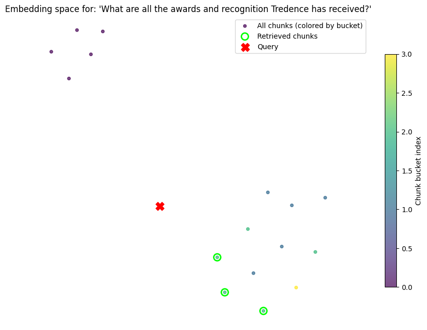

```
Top retrieved chunks (in order):
```

|  | id | chunk_index | text |
| --- | --- | --- | --- |
| 14 | tredence_chunk_14 | 14 | y recognized a Databricks Gold Partner\n\nTred... |
| 13 | tredence_chunk_13 | 13 | Leader in 2024 ISG's Lens™ Assessment for Gene... |
| 12 | tredence_chunk_12 | 12 | adrant for GenAI\n\nNamed a Leader in The Forr... |

```python
# INSTALL DEPENDENCIES (run once)
!pip install -q umap-learn scikit-learn

import numpy as np
import umap
import matplotlib.pyplot as plt
import pandas as pd

# 1. FETCH ALL EMBEDDINGS, METADATA, DOCUMENTS FROM CHROMA

# 'ids' are always returned; do NOT include them explicitly.
all_data = collection.get(include=["embeddings", "metadatas", "documents"])

all_embeddings = np.array(all_data["embeddings"])
all_ids = all_data["ids"]
all_metadatas = all_data["metadatas"]
all_docs = all_data["documents"]

# Build a DataFrame for inspection and coloring
corpus_df = pd.DataFrame({
    "id": all_ids,
    "embedding_idx": np.arange(len(all_ids)),
    "metadata": all_metadatas,
    "text": all_docs
})

# Extract chunk_index from metadata (if present)
def get_chunk_index(meta):
    if isinstance(meta, dict) and "chunk_index" in meta:
        return meta["chunk_index"]
    return -1  # fallback if not present

corpus_df["chunk_index"] = corpus_df["metadata"].apply(get_chunk_index)

# Bucket chunk_index for coloring (0–4, 5–9, etc.)
corpus_df["chunk_bucket"] = (corpus_df["chunk_index"] // 5).astype(int)

# 2. FIT UMAP ON FULL EMBEDDING SET

umap_transform = umap.UMAP(
    n_neighbors=15,
    min_dist=0.1,
    metric="cosine",
    random_state=0,
    transform_seed=0
).fit(all_embeddings)

# 3. VISUALIZATION FUNCTION

def visualize_query(question, n_results=TOP_K):
    """
    Visualize where a question and its retrieved chunks lie in the embedding space.
    """
    # a) Use the same retrieval logic from your RAG pipeline
    retrieved = retrieve_relevant_chunks(question, top_k=n_results)

    # b) Embed query and query Chroma to get embeddings of retrieved chunks
    q_emb = embed_texts([question])[0]
    q_results = collection.query(
        query_embeddings=[q_emb],
        n_results=n_results,
        include=["embeddings"]  # <--- FIX: no 'ids' here
    )
    # ids are returned regardless of `include`
    retrieved_ids = q_results["ids"][0]
    retrieved_embeddings = np.array(q_results["embeddings"][0])

    # c) Project all embeddings
    projected_all = umap_transform.transform(all_embeddings)

    # d) Project retrieved embeddings
    projected_retrieved = umap_transform.transform(retrieved_embeddings)

    # e) Project query embedding
    projected_query = umap_transform.transform(np.array([q_emb]))

    # f) Mask for retrieved points in the corpus
    retrieved_mask = corpus_df["id"].isin(retrieved_ids).values

    # 4. PLOT
    plt.figure(figsize=(10, 8))

    # Corpus points, colored by chunk_bucket
    buckets = corpus_df["chunk_bucket"].values
    scatter = plt.scatter(
        projected_all[:, 0],
        projected_all[:, 1],
        c=buckets,
        cmap="viridis",
        s=18,
        alpha=0.7,
        label="All chunks (colored by bucket)"
    )

    # Retrieved chunks (outlined)
    plt.scatter(
        projected_all[retrieved_mask, 0],
        projected_all[retrieved_mask, 1],
        s=100,
        facecolors="none",
        edgecolors="lime",
        linewidths=2,
        label="Retrieved chunks"
    )

    # Query embedding (red X)
    plt.scatter(
        projected_query[:, 0],
        projected_query[:, 1],
        s=140,
        marker="X",
        color="red",
        label="Query"
    )

    plt.gca().set_aspect("equal", "datalim")
    plt.title(f"Embedding space for: '{question}'")
    plt.axis("off")
    plt.legend(loc="upper right")

    # Optional colorbar for bucket index
    cbar = plt.colorbar(scatter, fraction=0.03, pad=0.04)
    cbar.set_label("Chunk bucket index")

    plt.show()

    # 5. TEXT INSPECTION TABLE OF RETRIEVED CHUNKS
    retrieved_df = corpus_df[corpus_df["id"].isin(retrieved_ids)].copy()
    # Order rows according to retrieval order
    retrieved_df["order"] = retrieved_df["id"].apply(lambda x: retrieved_ids.index(x))
    retrieved_df = retrieved_df.sort_values("order")

    display_cols = ["id", "chunk_index", "text"]
    print("\nTop retrieved chunks (in order):\n")
    display(retrieved_df[display_cols])

# EXAMPLE USAGE
visualize_query("What are all the awards and recognition Tredence has received?")
```

Step 6: Add a BM25 retriever over your chunks

```python
!pip install -q rank_bm25

from rank_bm25 import BM25Okapi
import numpy as np

class BM25Retriever:
    def __init__(self, documents):
        """
        documents: list of raw text strings (your chunks)
        """
        self.documents = documents
        self.tokenized_docs = [
            doc.lower().split()
            for doc in documents
        ]
        self.bm25 = BM25Okapi(self.tokenized_docs)
        print(f"BM25 index created with {len(documents)} documents")

    def search(self, query, k=3):
        """
        Return top k documents with scores.
        """
        tokenized_query = query.lower().split()
        scores = self.bm25.get_scores(tokenized_query)
        top_k_idx = np.argsort(scores)[::-1][:k]
        return [(self.documents[i], scores[i]) for i in top_k_idx]

# Create BM25 retriever over your existing chunks
bm25_retriever = BM25Retriever(chunks)
```

```
BM25 index created with 16 documents
```

```python
bm25_retriever.search("Tredence services", k=3)
```

```
[("adrant for GenAI\n\nNamed a Leader in The Forrester Wave™: Customer Analytics Services, Q2 2025\n\nLeader & Star Performer in the Everest Group PEAK Matrix\n\nTredence Named a ‘#1 Leader’ in 2025 ISG Provider Lens Report for Retail & CPG Analytics Services\n\nTredence Named the 2026 Google Cloud …
  1.4129805225911136),
 ("Leader in 2024 ISG's Lens™ Assessment for Generative AI Services\n\nLeader in ISG Provider Lens™ Data Engineering Specialty Analytics Services 2024\n\nLeader in ISG Provider Lens™ Data Science Specialty Analytics Services 2024\n\nLeader in 2025 Gartner Emerging\nMarket Quadrant for GenAI\n\nNamed…
  1.3019603056935976),
 ("\n                                                        reality with\r\n                                                        our accelerators.\n\n\n\n\n\n\n\n\n\n\n\n\n\nWith RAPID — Tredence's Agentic Business Process Modernization solution, replace manual, decision-heavy processes with int…
  1.285430214598357)]
```

Step 7: Add a cross-encoder reranker

```python
!pip install -q sentence-transformers

from sentence_transformers import CrossEncoder

class CrossEncoderReranker:
    def __init__(self, model_name="cross-encoder/ms-marco-MiniLM-L-6-v2"):
        print(f"Loading cross-encoder: {model_name}...")
        self.model = CrossEncoder(model_name)
        print("Re-ranker ready")

    def rerank(self, query, documents, top_k=3):
        """
        documents: list of raw text strings (chunks)
        Returns list of (doc_text, score) sorted by score desc.
        """
        if not documents:
            return []

        pairs = [[query, doc] for doc in documents]
        scores = self.model.predict(pairs)

        ranked = sorted(
            zip(documents, scores),
            key=lambda x: x[1],
            reverse=True
        )

        return ranked[:top_k]

# Initialize re-ranker
reranker = CrossEncoderReranker()
```

```
Loading cross-encoder: cross-encoder/ms-marco-MiniLM-L-6-v2...
```

```
Re-ranker ready
```

Step 8: Build a HybridRAG system around your existing components

```python
class HybridRAGSystem:
    """
    Hybrid RAG combining:
      - Vector search via Chroma
      - BM25 keyword search
      - Cross-encoder re-ranking
    """

    def __init__(self, collection, bm25_retriever, reranker, embed_fn, llm_client):
        self.collection = collection
        self.bm25_retriever = bm25_retriever
        self.reranker = reranker
        self.embed_fn = embed_fn
        self.llm_client = llm_client

    def vector_search(self, query, k=10):
        """
        Use Chroma for semantic retrieval; returns list of chunk texts.
        """
        q_emb = self.embed_fn([query])[0]
        results = self.collection.query(
            query_embeddings=[q_emb],
            n_results=k,
            include=["documents"]
        )
        docs = results["documents"][0]
        return docs

    def retrieve_hybrid(self, query, k_vector=10, k_bm25=10):
        """
        Hybrid candidate set: union of vector and BM25 results (deduplicated).
        """
        vector_docs = self.vector_search(query, k=k_vector)
        bm25_results = self.bm25_retriever.search(query, k=k_bm25)
        bm25_docs = [doc for doc, _ in bm25_results]

        seen = set()
        combined = []
        for doc in vector_docs + bm25_docs:
            h = hash(doc)
            if h not in seen:
                seen.add(h)
                combined.append(doc)

        return combined

    def generate_answer(self, question, context_docs):
        """
        Call OpenAI chat model using combined context.
        """
        context = "\n\n".join(context_docs)

        system_prompt = (
            "You are a helpful assistant answering questions based ONLY on the "
            "provided website content. If the answer is not in the context, say "
            "you don't know and suggest the user check the website."
        )

        user_prompt = (
            f"Question: {question}\n\n"
            f"Context from the Tredence website:\n{context}\n\n"
            "Answer the question using only this context. "
            "Be concise but complete."
        )

        response = self.llm_client.chat.completions.create(
            model="gpt-4o-mini",
            messages=[
                {"role": "system", "content": system_prompt},
                {"role": "user", "content": user_prompt}
            ]
        )

        return response.choices[0].message.content

    def query(self, question, k_retrieve=10, k_rerank=3):
        """
        Full hybrid RAG pipeline.
        """
        # Step 1: Hybrid retrieval
        candidates = self.retrieve_hybrid(question, k_vector=k_retrieve, k_bm25=k_retrieve)

        # Step 2: Re-rank
        reranked = self.reranker.rerank(question, candidates, top_k=k_rerank)
        final_docs = [doc for doc, score in reranked]
        final_scores = [score for doc, score in reranked]

        # Step 3: Generate answer
        answer = self.generate_answer(question, final_docs)

        return {
            "answer": answer,
            "source_documents": final_docs,
            "scores": final_scores,
            "num_retrieved": len(candidates)
        }

# Create the hybrid system
hybrid_rag = HybridRAGSystem(
    collection=collection,
    bm25_retriever=bm25_retriever,
    reranker=reranker,
    embed_fn=embed_texts,
    llm_client=client
)

# Quick test
test_q = "What services does Tredence provide?"
result = hybrid_rag.query(test_q, k_retrieve=10, k_rerank=3)

print("\n=== ANSWER ===\n")
print(result["answer"])
print(f"\nSources used: {len(result['source_documents'])}")
for i, (doc, score) in enumerate(zip(result["source_documents"], result["scores"]), 1):
    print(f"\n[{i}] Re-rank score: {score:.4f}")
    print(doc[:200], "...")
```

```
=== ANSWER ===

Tredence provides a variety of services including:

- Agentic AI
- Generative AI
- Supply Chain Management
- Data Engineering
- Data Modernization
- Customer Experience (CX) Analytics
- MLOps (Machine Learning Operations)
- Data Science
- Digital Engineering
- Supply Chain Control Tower
- Test and Learn Platform (TALP)
- On-shelf Availability (OSA)
- Customer Cosmos

Additionally, Tredence offers solutions such as RAPID, which is focused on Business Process Modernization using intelligent agents.

Sources used: 3

[1] Re-rank score: 4.7458
y recognized a Databricks Gold Partner

Tredence is Certified as a Great Place to Work® by GPTW India

Recognized as a Top Management Consulting Firm in the U.S. by Business Insider.

Tredence named i ...

[2] Re-rank score: 4.6238

                                                        reality with
                                                        our accelerators.













With RAPID — Tredence's Agentic Business P ...

[3] Re-rank score: 4.4655
adrant for GenAI

Named a Leader in The Forrester Wave™: Customer Analytics Services, Q2 2025

Leader & Star Performer in the Everest Group PEAK Matrix

Tredence Named a ‘#1 Leader’ in 2025 ISG Provid ...
```

Step 9: Wire hybrid RAG into your chatbot UI

```python
!pip install -q gradio

import gradio as gr

def rag_chatbot(message, history):
    if not message or message.strip() == "":
        return "Please ask a question about the Tredence website."

    result = hybrid_rag.query(message, k_retrieve=10, k_rerank=3)
    reply = result["answer"]
    return reply

demo = gr.ChatInterface(
    fn=rag_chatbot,
    title="Tredence Website Q&A",
    description="Ask questions about the Tredence homepage (RAG over scraped content)."
)

demo.launch()
```

```
* Running on local URL:  http://127.0.0.1:7861
* To create a public link, set `share=True` in `launch()`.
```

[interactive chart not shown]

Step 10: Update visualization to reflect hybrid pipeline

```python
def visualize_query_hybrid(question, n_results=TOP_K):
    """
    Visualize final reranked top-k documents from the hybrid pipeline.
    """
    # Run hybrid pipeline but capture candidates and final docs
    # Reuse the internal pieces directly for visualization.
    candidates = hybrid_rag.retrieve_hybrid(question, k_vector=n_results*3, k_bm25=n_results*3)
    reranked = hybrid_rag.reranker.rerank(question, candidates, top_k=n_results)
    final_docs = [doc for doc, score in reranked]

    # Embed query and project as before
    q_emb = embed_texts([question])[0]
    q_results = collection.query(
        query_embeddings=[q_emb],
        n_results=len(all_embeddings),  # just to confirm embeddings exist
        include=["embeddings"]
    )

    # Project all embeddings
    projected_all = umap_transform.transform(all_embeddings)

    # Map final_docs (strings) back to ids via corpus_df.text
    final_mask = corpus_df["text"].isin(final_docs).values

    projected_query = umap_transform.transform(np.array([q_emb]))

    plt.figure(figsize=(10, 8))

    buckets = corpus_df["chunk_bucket"].values
    scatter = plt.scatter(
        projected_all[:, 0],
        projected_all[:, 1],
        c=buckets,
        cmap="viridis",
        s=18,
        alpha=0.7,
        label="All chunks"
    )

    plt.scatter(
        projected_all[final_mask, 0],
        projected_all[final_mask, 1],
        s=100,
        facecolors="none",
        edgecolors="orange",
        linewidths=2,
        label="Hybrid RAG top-k"
    )

    plt.scatter(
        projected_query[:, 0],
        projected_query[:, 1],
        s=140,
        marker="X",
        color="red",
        label="Query"
    )

    plt.gca().set_aspect("equal", "datalim")
    plt.title(f"Hybrid RAG embedding space for: '{question}'")
    plt.axis("off")
    plt.legend(loc="upper right")
    plt.colorbar(scatter, fraction=0.03, pad=0.04).set_label("Chunk bucket index")
    plt.show()

    print("\nHybrid RAG top-k documents:\n")
    for i, (doc, score) in enumerate(reranked, 1):
        print(f"[{i}] Score: {score:.4f}")
        print(doc[:200], "...\n")
```

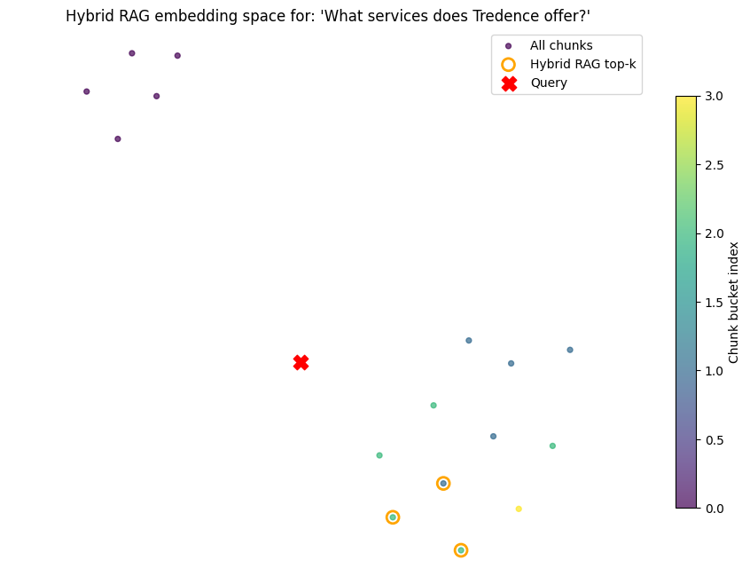

```
Hybrid RAG top-k documents:

[1] Score: 4.3176

                                                        reality with
                                                        our accelerators.













With RAPID — Tredence's Agentic Business P ...

[2] Score: 4.0215
y recognized a Databricks Gold Partner

Tredence is Certified as a Great Place to Work® by GPTW India

Recognized as a Top Management Consulting Firm in the U.S. by Business Insider.

Tredence named i ...

[3] Score: 3.8276
adrant for GenAI

Named a Leader in The Forrester Wave™: Customer Analytics Services, Q2 2025

Leader & Star Performer in the Everest Group PEAK Matrix

Tredence Named a ‘#1 Leader’ in 2025 ISG Provid ...
```

```python
visualize_query_hybrid("What services does Tredence offer?")
```

step 10 : Two chunk-size configurations

```python
# Two chunking configurations for comparison
SMALL_CHUNK_SIZE = 500
SMALL_CHUNK_OVERLAP = 100

LARGE_CHUNK_SIZE = 1000
LARGE_CHUNK_OVERLAP = 200

def chunk_text(text, chunk_size, chunk_overlap):
    """
    Simple character-based chunking with overlap.
    """
    if not text:
        return []

    chunks = []
    start = 0
    text_length = len(text)

    while start < text_length:
        end = start + chunk_size
        chunk = text[start:end]
        chunks.append(chunk)
        start += chunk_size - chunk_overlap

    return chunks

page_text = docs_df.loc[0, "text"]

# Small chunks
chunks_small = chunk_text(
    page_text,
    chunk_size=SMALL_CHUNK_SIZE,
    chunk_overlap=SMALL_CHUNK_OVERLAP
)

# Large chunks
chunks_large = chunk_text(
    page_text,
    chunk_size=LARGE_CHUNK_SIZE,
    chunk_overlap=LARGE_CHUNK_OVERLAP
)

print(f"Small config: size={SMALL_CHUNK_SIZE}, overlap={SMALL_CHUNK_OVERLAP}, num_chunks={len(chunks_small)}")
print(f"Large config: size={LARGE_CHUNK_SIZE}, overlap={LARGE_CHUNK_OVERLAP}, num_chunks={len(chunks_large)}")
print("\nSmall chunk preview:\n", chunks_small[0][:600])
print("\nLarge chunk preview:\n", chunks_large[0][:600])
```

```
Small config: size=500, overlap=100, num_chunks=35
Large config: size=1000, overlap=200, num_chunks=18

Small chunk preview:
 Move ideas from
                                                        experimentation to
                                                        reality with
                                                        our accelerators.

Move ideas from experimentation
                                                        to reality with
                                                        our accelerators.

Move ideas from
                                                        experime

Large chunk preview:
 Move ideas from
                                                        experimentation to
                                                        reality with
                                                        our accelerators.

Move ideas from experimentation
                                                        to reality with
                                                        our accelerators.

Move ideas from
                                                        experimentation to
                                                        reality with
```

step 11: Build two Chroma collections (small vs large)

```python
from chromadb import PersistentClient

# Use the same persistent directory, but different collection names
chroma_client = PersistentClient(path="./tredence_rag_db")

# Collections for each chunking strategy
collection_small = chroma_client.get_or_create_collection(name="tredence_small_chunks")
collection_large = chroma_client.get_or_create_collection(name="tredence_large_chunks")

def embed_texts(texts):
    """
    Use OpenAI embeddings for a list of strings.
    """
    response = client.embeddings.create(
        model="text-embedding-3-small",
        input=texts
    )
    return [item.embedding for item in response.data]

# Add small chunks
small_ids = [f"tredence_small_{i}" for i in range(len(chunks_small))]
small_metadatas = [
    {"url": docs_df.loc[0, "url"], "chunk_index": i, "chunk_config": "small"}
    for i in range(len(chunks_small))
]
small_embeddings = embed_texts(chunks_small)

collection_small.add(
    ids=small_ids,
    documents=chunks_small,
    embeddings=small_embeddings,
    metadatas=small_metadatas
)

print(f"Small collection: {collection_small.count()} documents")

# Add large chunks
large_ids = [f"tredence_large_{i}" for i in range(len(chunks_large))]
large_metadatas = [
    {"url": docs_df.loc[0, "url"], "chunk_index": i, "chunk_config": "large"}
    for i in range(len(chunks_large))
]
large_embeddings = embed_texts(chunks_large)

collection_large.add(
    ids=large_ids,
    documents=chunks_large,
    embeddings=large_embeddings,
    metadatas=large_metadatas
)

print(f"Large collection: {collection_large.count()} documents")
```

```
Small collection: 35 documents
Large collection: 18 documents
```

step 12: Visualization function that accepts a collection + config

```python
import numpy as np
import umap
import matplotlib.pyplot as plt
import pandas as pd

def prepare_corpus_for_collection(collection, config_label):
    """
    Fetch embeddings, ids, metadatas, documents from a given collection
    and build a corpus DataFrame.
    """
    all_data = collection.get(include=["embeddings", "metadatas", "documents"])
    all_embeddings = np.array(all_data["embeddings"])
    all_ids = all_data["ids"]
    all_metadatas = all_data["metadatas"]
    all_docs = all_data["documents"]

    corpus_df = pd.DataFrame({
        "id": all_ids,
        "embedding_idx": np.arange(len(all_ids)),
        "metadata": all_metadatas,
        "text": all_docs
    })

    def get_chunk_index(meta):
        if isinstance(meta, dict) and "chunk_index" in meta:
            return meta["chunk_index"]
        return -1

    corpus_df["chunk_index"] = corpus_df["metadata"].apply(get_chunk_index)
    corpus_df["chunk_bucket"] = (corpus_df["chunk_index"] // 5).astype(int)
    corpus_df["config"] = config_label

    return all_embeddings, corpus_df

# Prepare corpus for both configs
embeddings_small, corpus_small = prepare_corpus_for_collection(collection_small, "small")
embeddings_large, corpus_large = prepare_corpus_for_collection(collection_large, "large")

def visualize_query_for_collection(question, collection, embeddings, corpus_df, title_suffix=""):
    """
    Visualize query + retrieved chunks for a specific collection (chunk config).
    """
    # Fit UMAP on this collection's embeddings
    umap_transform = umap.UMAP(
        n_neighbors=15,
        min_dist=0.1,
        metric="cosine",
        random_state=0,
        transform_seed=0
    ).fit(embeddings)

    # Embed query
    q_emb = embed_texts([question])[0]

    # Query collection for top-k chunks
    TOP_K = 3
    results = collection.query(
        query_embeddings=[q_emb],
        n_results=TOP_K,
        include=["embeddings"]
    )
    retrieved_ids = results["ids"][0]
    retrieved_embeddings = np.array(results["embeddings"][0])

    # Project corpus, retrieved, and query
    projected_all = umap_transform.transform(embeddings)
    projected_retrieved = umap_transform.transform(retrieved_embeddings)
    projected_query = umap_transform.transform(np.array([q_emb]))

    # Mask for retrieved points
    retrieved_mask = corpus_df["id"].isin(retrieved_ids).values

    plt.figure(figsize=(10, 8))

    buckets = corpus_df["chunk_bucket"].values
    scatter = plt.scatter(
        projected_all[:, 0],
        projected_all[:, 1],
        c=buckets,
        cmap="viridis",
        s=18,
        alpha=0.7,
        label="All chunks"
    )

    plt.scatter(
        projected_all[retrieved_mask, 0],
        projected_all[retrieved_mask, 1],
        s=100,
        facecolors="none",
        edgecolors="lime",
        linewidths=2,
        label="Retrieved chunks"
    )

    plt.scatter(
        projected_query[:, 0],
        projected_query[:, 1],
        s=140,
        marker="X",
        color="red",
        label="Query"
    )

    plt.gca().set_aspect("equal", "datalim")
    plt.title(f"Embedding space ({title_suffix}) for: '{question}'")
    plt.axis("off")
    plt.legend(loc="upper right")
    cbar = plt.colorbar(scatter, fraction=0.03, pad=0.04)
    cbar.set_label("Chunk bucket index")
    plt.show()

    # Print retrieved chunks for inspection
    retrieved_df = corpus_df[corpus_df["id"].isin(retrieved_ids)].copy()
    retrieved_df["order"] = retrieved_df["id"].apply(lambda x: retrieved_ids.index(x))
    retrieved_df = retrieved_df.sort_values("order")

    print(f"\nRetrieved chunks ({title_suffix} config):\n")
    display(retrieved_df[["id", "chunk_index", "text"]])
```

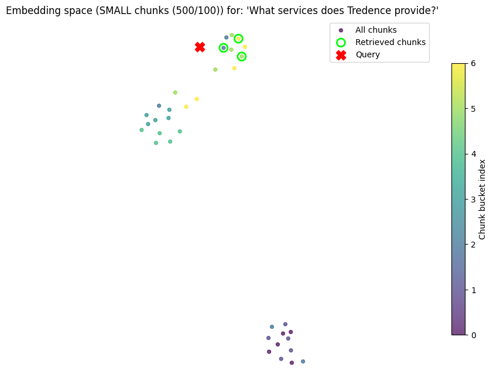

```
Retrieved chunks (SMALL chunks (500/100) config):
```

|  | id | chunk_index | text |
| --- | --- | --- | --- |
| 30 | tredence_small_30 | 30 | The Forrester Wave™: Customer Analytics Servi... |
| 29 | tredence_small_29 | 29 | Business Insider.\n\nTredence named in Inc. 50... |
| 13 | tredence_small_13 | 13 | f the Year 2026, for the Second Consecutive Ye... |

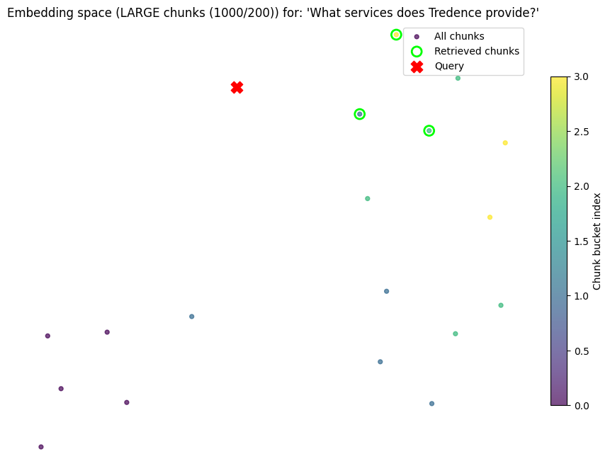

```
Retrieved chunks (LARGE chunks (1000/200) config):
```

|  | id | chunk_index | text |
| --- | --- | --- | --- |
| 6 | tredence_large_6 | 6 | reason, act, and deliver.\n\nRun Enterprise B... |
| 14 | tredence_large_14 | 14 | rm Partner of the Year\n\nNamed Databricks 202... |
| 15 | tredence_large_15 | 15 | The Forrester Wave™: Customer Analytics Servi... |

```python
query = "What services does Tredence provide?"

visualize_query_for_collection(
    question=query,
    collection=collection_small,
    embeddings=embeddings_small,
    corpus_df=corpus_small,
    title_suffix="SMALL chunks (500/100)"
)

visualize_query_for_collection(
    question=query,
    collection=collection_large,
    embeddings=embeddings_large,
    corpus_df=corpus_large,
    title_suffix="LARGE chunks (1000/200)"
)
```

step 13: Multi-query visualization section

```
=== Visualization for query: 'What services does Tredence provide?' (SMALL chunks) ===
```

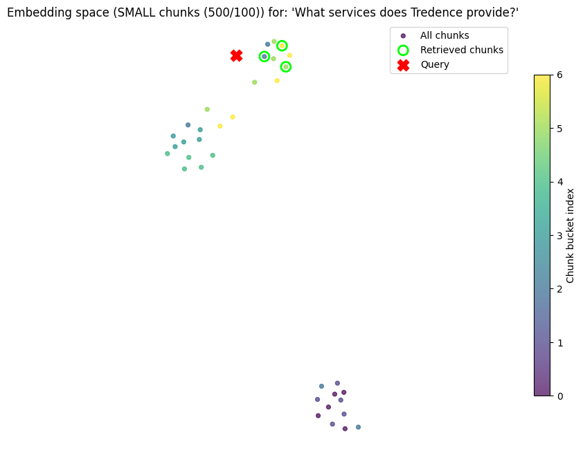

```
Retrieved chunks (SMALL chunks (500/100) config):
```

|  | id | chunk_index | text |
| --- | --- | --- | --- |
| 30 | tredence_small_30 | 30 | The Forrester Wave™: Customer Analytics Servi... |
| 29 | tredence_small_29 | 29 | Business Insider.\n\nTredence named in Inc. 50... |
| 13 | tredence_small_13 | 13 | f the Year 2026, for the Second Consecutive Ye... |

```
=== Visualization for query: 'What services does Tredence provide?' (LARGE chunks) ===
```

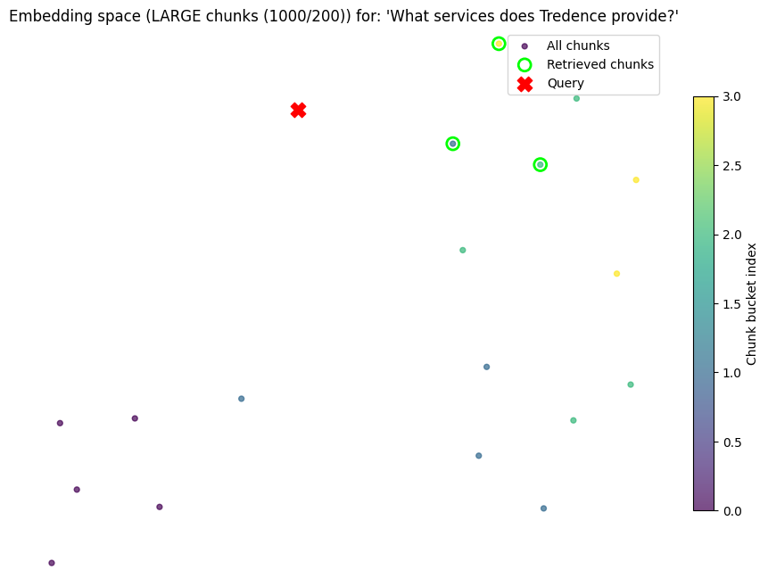

```
Retrieved chunks (LARGE chunks (1000/200) config):
```

|  | id | chunk_index | text |
| --- | --- | --- | --- |
| 6 | tredence_large_6 | 6 | reason, act, and deliver.\n\nRun Enterprise B... |
| 14 | tredence_large_14 | 14 | rm Partner of the Year\n\nNamed Databricks 202... |
| 15 | tredence_large_15 | 15 | The Forrester Wave™: Customer Analytics Servi... |

```
=== Visualization for query: 'Which industries does Tredence serve?' (SMALL chunks) ===
```

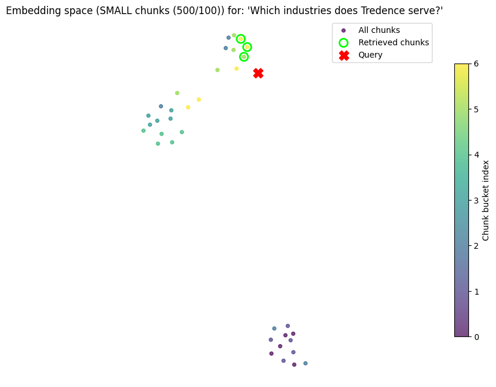

```
Retrieved chunks (SMALL chunks (500/100) config):
```

|  | id | chunk_index | text |
| --- | --- | --- | --- |
| 29 | tredence_small_29 | 29 | Business Insider.\n\nTredence named in Inc. 50... |
| 30 | tredence_small_30 | 30 | The Forrester Wave™: Customer Analytics Servi... |
| 31 | tredence_small_31 | 31 | ricks 2025 Americas Growth Partner of the Year... |

```
=== Visualization for query: 'Which industries does Tredence serve?' (LARGE chunks) ===
```

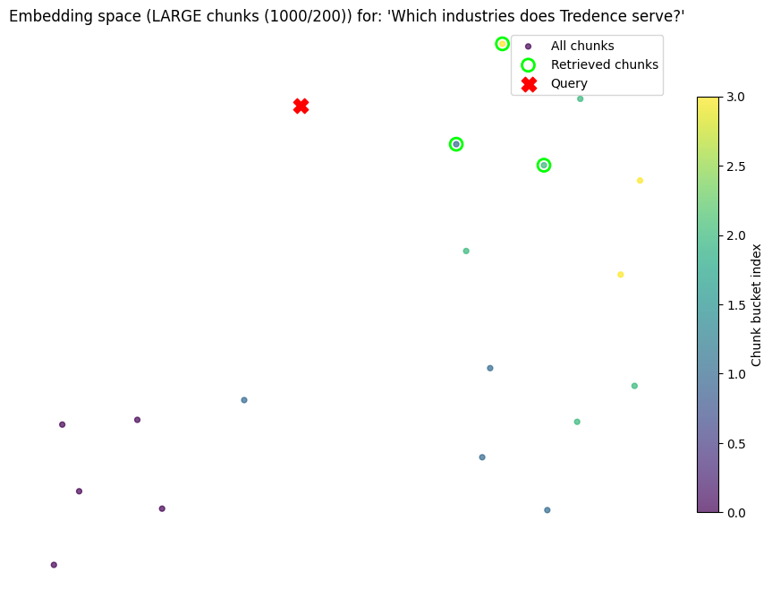

```
Retrieved chunks (LARGE chunks (1000/200) config):
```

|  | id | chunk_index | text |
| --- | --- | --- | --- |
| 15 | tredence_large_15 | 15 | The Forrester Wave™: Customer Analytics Servi... |
| 14 | tredence_large_14 | 14 | rm Partner of the Year\n\nNamed Databricks 202... |
| 6 | tredence_large_6 | 6 | reason, act, and deliver.\n\nRun Enterprise B... |

```
=== Visualization for query: 'What awards has Tredence won?' (SMALL chunks) ===
```

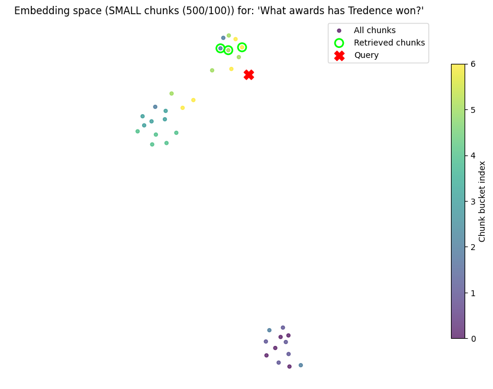

```
Retrieved chunks (SMALL chunks (500/100) config):
```

|  | id | chunk_index | text |
| --- | --- | --- | --- |
| 31 | tredence_small_31 | 31 | ricks 2025 Americas Growth Partner of the Year... |
| 28 | tredence_small_28 | 28 | rm Partner of the Year\n\nNamed Databricks 202... |
| 13 | tredence_small_13 | 13 | f the Year 2026, for the Second Consecutive Ye... |

```
=== Visualization for query: 'What awards has Tredence won?' (LARGE chunks) ===
```

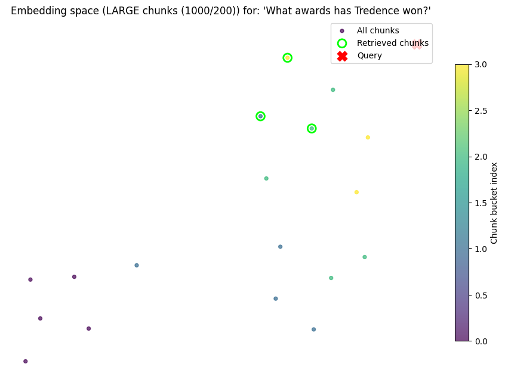

```
Retrieved chunks (LARGE chunks (1000/200) config):
```

|  | id | chunk_index | text |
| --- | --- | --- | --- |
| 14 | tredence_large_14 | 14 | rm Partner of the Year\n\nNamed Databricks 202... |
| 15 | tredence_large_15 | 15 | The Forrester Wave™: Customer Analytics Servi... |
| 6 | tredence_large_6 | 6 | reason, act, and deliver.\n\nRun Enterprise B... |

```
=== Visualization for query: 'What is Tredence's AIML accelerator ecosystem?' (SMALL chunks) ===
```

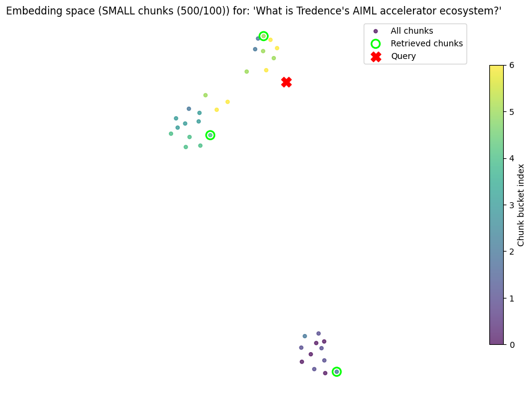

```
Retrieved chunks (SMALL chunks (500/100) config):
```

|  | id | chunk_index | text |
| --- | --- | --- | --- |
| 24 | tredence_small_24 | 24 | omer intelligence.\n\nCreate intelligent inter... |
| 11 | tredence_small_11 | 11 | ators.\n\nMove ideas from\r\n ... |
| 27 | tredence_small_27 | 27 | adrant for GenAI\n\nNamed a Leader in The Forr... |

```
=== Visualization for query: 'What is Tredence's AIML accelerator ecosystem?' (LARGE chunks) ===
```

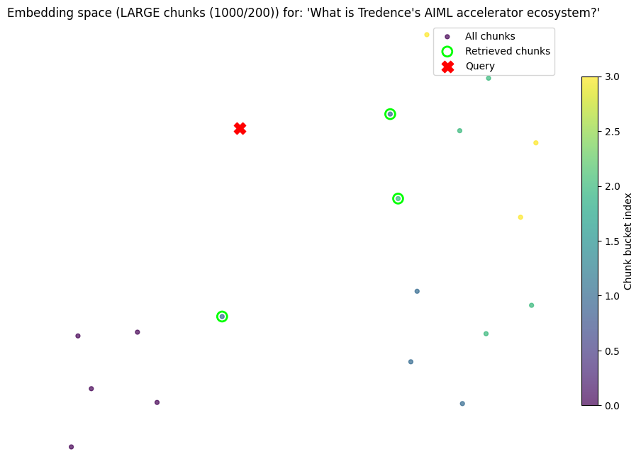

```
Retrieved chunks (LARGE chunks (1000/200) config):
```

|  | id | chunk_index | text |
| --- | --- | --- | --- |
| 12 | tredence_large_12 | 12 | omer intelligence.\n\nCreate intelligent inter... |
| 6 | tredence_large_6 | 6 | reason, act, and deliver.\n\nRun Enterprise B... |
| 5 | tredence_large_5 | 5 | experimentation to\r\n ... |

```
=== Visualization for query: 'How does Tredence help with supply chain management?' (SMALL chunks) ===
```

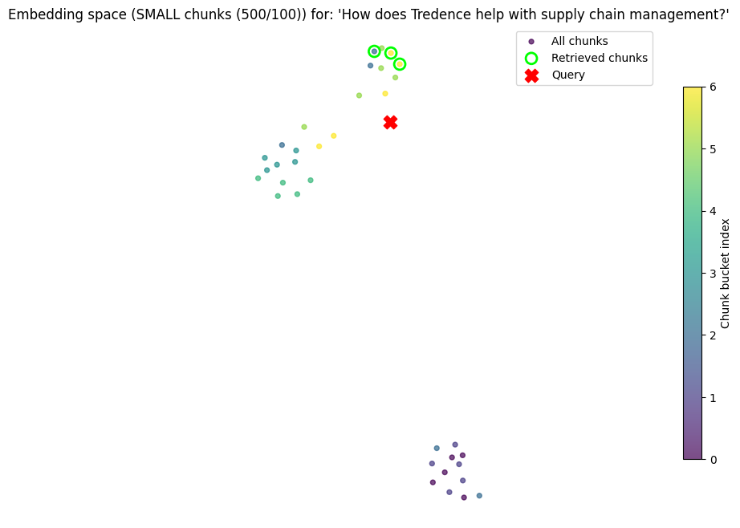

```
Retrieved chunks (SMALL chunks (500/100) config):
```

|  | id | chunk_index | text |
| --- | --- | --- | --- |
| 31 | tredence_small_31 | 31 | ricks 2025 Americas Growth Partner of the Year... |
| 12 | tredence_small_12 | 12 | reason, act, and deliver.\n\nRun Enterprise B... |
| 30 | tredence_small_30 | 30 | The Forrester Wave™: Customer Analytics Servi... |

```
=== Visualization for query: 'How does Tredence help with supply chain management?' (LARGE chunks) ===
```

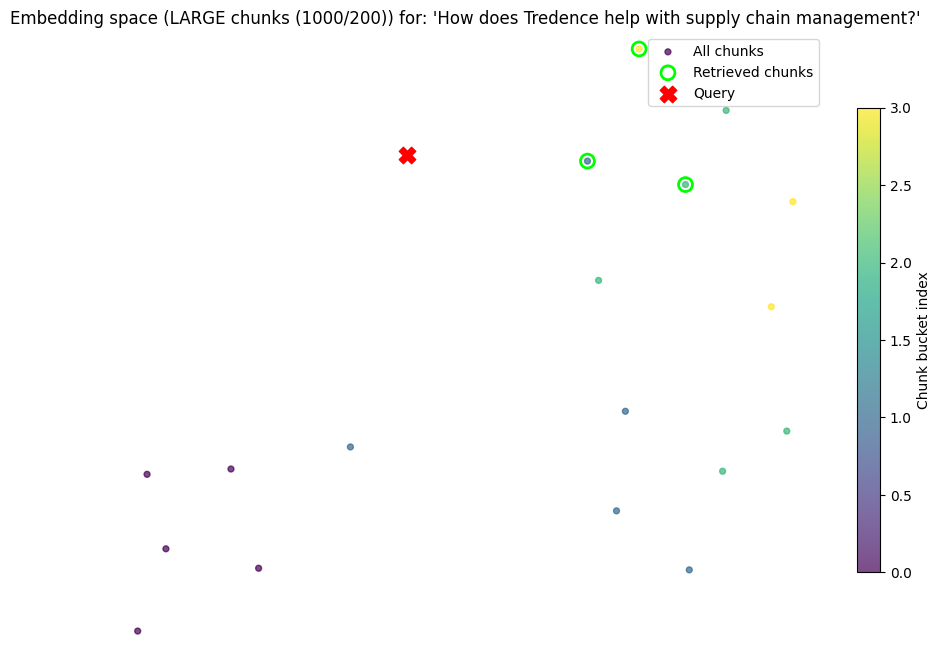

```
Retrieved chunks (LARGE chunks (1000/200) config):
```

|  | id | chunk_index | text |
| --- | --- | --- | --- |
| 6 | tredence_large_6 | 6 | reason, act, and deliver.\n\nRun Enterprise B... |
| 14 | tredence_large_14 | 14 | rm Partner of the Year\n\nNamed Databricks 202... |
| 15 | tredence_large_15 | 15 | The Forrester Wave™: Customer Analytics Servi... |

```python
# A set of diverse queries about the Tredence website
queries = [
    "What services does Tredence provide?",
    "Which industries does Tredence serve?",
    "What awards has Tredence won?",
    "What is Tredence's AIML accelerator ecosystem?",
    "How does Tredence help with supply chain management?"
]

for q in queries:
    print(f"\n=== Visualization for query: '{q}' (SMALL chunks) ===")
    visualize_query_for_collection(
        question=q,
        collection=collection_small,
        embeddings=embeddings_small,
        corpus_df=corpus_small,
        title_suffix="SMALL chunks (500/100)"
    )

    print(f"\n=== Visualization for query: '{q}' (LARGE chunks) ===")
    visualize_query_for_collection(
        question=q,
        collection=collection_large,
        embeddings=embeddings_large,
        corpus_df=corpus_large,
        title_suffix="LARGE chunks (1000/200)"
    )
```

## Conclusion: Tredence RAG Chatbot with Hybrid Retrieval and Visualization

For visualization, UMAP was applied to the document embeddings to project the high-dimensional vector space into two dimensions. The plots show all chunk embeddings (colored by chunk bucket), the query embedding, and the retrieved chunks, allowing inspection of how the query sits in the corpus and which regions are activated by retrieval. By varying chunk size/overlap (e.g., 500/100 vs 1000/200) and by changing the query itself, separate visualizations were generated to illustrate how chunking strategy and question choice impact the embedding distribution and retrieval behavior.

Overall, the assignment delivers: (1) web scraping of the Tredence website, (2) basic and hybrid RAG pipelines with reranking, (3) a Q&A chatbot answering multiple diverse questions, and (4) clear visualizations of query and document vectors under different chunking and query settings, satisfying all specified requirements.